# Lecture: Course introduction

## Friendly faces

- Course director: Mark Clements ([mailto:mark.clements@ki.se](mailto:mark.clements@ki.se))
- Course administrator: Kristina Leif ([mailto:kristina.leif@ki.se](mailto:kristina.leif@ki.se))
- Teachers: Paul Dickman (and others).

## Overview of the course

| Week | Topic |
| --- | --- |
| 4 | Introduction |
|  | Survival and hazard estimation |
| 5 | Counting processes |
|  | Likelihood derivations |
| 6 | Poisson regression |
| 7 | Cox regression |
| 8 | Standard parametric models |
|  | Flexible parametric models |
| 9 | Frailty models and non-collapsibility |
|  | Recurrent events |
| 10 | Joint models; interval censoring |
|  | Restricted mean survival; prediction |
| 11 | Competing events |
|  | Multistate models |
| 12 | Dependent censoring, illness-death models |
|  | Relative survival |
| 13 | Exam work |

## Teaching format

- The classroom will be a mixture of **lectures** and **group activities**.
  - The lectures will be based primarily on Collett [@collett2023modelling], with some input from Aalen et [@Aalen_Borgan_Gjessing_2008] and other material.
  - The group activities will include:
    - Working on computing examples.
    - Working on mathematical derivations.
    - Discussions of specific journal articles.
    - Reporting on the computing problems, mathematical derivations and journal discussions.
- We have computing examples for some of the material. Those examples currently use Quarto with webR for interactive use. Some of you may prefer Rmarkdown (for discussion).
- There is also a **collett** package on CRAN (https://CRAN.R-project.org/package=collett) that we will develop during the course.

## Learning outcomes

- The course aims to equip the student with an understanding of fundamental concepts in survival analysis (censoring, truncation, timescales, and the hazard and survival functions) and methods for modelling time-to-event (survival) data, including a rigorous statistical formulation of the likelihoods and partial likelihoods, along with the competence, skills, and judgement to appropriately apply such methods in biomedical research.
- Upon completion of the course, the student should be able to:
  - Regarding knowledge and understanding:
    - Define key concepts in survival analysis, including censoring and truncation, and explain the relevance of these concepts for the analysis of time-to-event data in biomedical research.
    - Understand the concept of timescales in statistical models for time-to-event data.
  - Regarding competence and skills:
    - Estimate and compare survival functions and state probabilities using parametric and non-parametric methods, including testing for and modelling time-varying effects.
    - Propose a suitable statistical model for assessing a specific research hypothesis using data from a time-to-event study, fit the model using standard statistical software, evaluate the fit of the model, and interpret the results.
    - Be able to control for different timescales using standard statistical software, and argue for an appropriate timescale for a given research hypothesis.
    - Understand how to assess discrimination and calibration for predictions based on time-to-event models.
  - Regarding judgement and approach:
    - Critically evaluate the methodological aspects (design and analysis) of a scientific article in biomedicine reporting a time-to-event study.

## Assessment

- For formative assessment, there were will be a group project due at the end of week 9. The project will involve coding and a presentation. The evaluation will be pass/fail.
- For summative assessment, there will be an individual-based written take-home examination during the last week of the course. The evaluation will be VG/G/U.
- Detailed assessment criteria will be provided.

## Take-home examination

- The course grade is based solely on an individual-based take-home written examination. The exam requires you to understand the concepts of survival analysis, and to code and interpret data analyses based on R. Instructions:
  - The examination is individual-based: **you are not allowed to cooperate with anyone** – although you are encouraged to consult the available literature. The teachers will use iThenticate to check for plagiarism.
- Do not write answers by hand: please use Word, LaTeX or a similar format for your examination report.
- Motivate all answers and show all computer code, output and calculations in your examination report, but write succinctly. Define any notation that you use for equations. The examination report should be written in English.
- You are expected to be able to write R computer code and interpret its output.
- You should declare your use of generative AI (see next slide)

## Use of generative AI in the course

- For guidelines on the use of generative AI, see https://staff.ki.se/education-support/organisation-of-higher-education-at-ki/programme-committee-for-the-study-programmes-in-biomedicine
- Generative AI are important resources – you should use them:)
- **Importantly, you should declare how you have used generative AI in your exam**
- I strongly encourage you **to understand any code that you use from generative AI**. If you do not understand the code, then it may not do what you want…

## Software used in the course

- I will primarily use **R** for this course.
  - The exercises and exam should be completed using R (TODO: discuss alternatives).
  - Only use R packages that have been used in the course. For some of the exercises, I have suggested adding one additional R package – but those additional packages should not be used for the exam.
- We will use **Quarto/Rmarkdown** for some of the exercises. We will experiment with using **webR** with Quarto for interactive examples (the `collett` package has not yet found its way from CRAN to the webR archive).
- The lecture material uses **Org Mode** (another text-based markup that depends on the **Emacs** editor), but you are not expected to use either Org Mode or Emacs:)
- Statisticians have been contributing code to R (and previously to **S+**) for a long time (30–40 years), so that there is a **large body of code** available. The quality of the code varies from excellent to … poor.
- R probably has the most extensive functionality for time-to-event analyses.
- **Stata** has arguably the next most extensive functionality for time-to-event analyses. Paul Dickman and Therese Andersson are both strong Stata users.
- **SAS** includes some time-to-event procedures. I like its implementation of time-varying Cox regression.
- **SPSS** has comparatively limited time-to-event functionality.
- **Julia** has comparatively limited time-to-event functionality. Watch this space.
- **Python** has comparatively limited time-to-event functionality. Watch this space.
  - The **lifelines** package (https://lifelines.readthedocs.io) is a good start. Interestingly, lifelines includes a model (`CRCSplineFitter`) that is based on our research:).
  - **pycox** is a very nice package for using Cox regression with neural networks using **PyTorch**. Classy stuff.

## Outline of today's material

- Definitions and mathematical relationships
- Types of time-to-event data
- Non-parametric survival estimation
- Hazard estimation
- Testing for differences in survival

## Definitions (group work)

**Guidance: within your group, discuss the following questions and be prepared to discuss your findings with the class.**

Consider a random variable $T$ for the time to some event. Initially consider that $T$ is **discrete**. Questions:

1. Mathematically define the **cumulative distribution function** and **probability mass function** for $T$.
2. Let **survival** be defined as one minus the cumulative distribution function. Does this definition "make sense"?
3. Let the **discrete time hazard** for $T$ at time $t_i$ be defined as the probability mass function divided by the survival function at time $t_{i-1}$. How would you interpret this function?

**Guidance: within your group, discuss the following questions and be prepared to discuss your findings with the class.**

Now consider that $T$ is **absolutely continuous**. Questions:

1. Based on your previous courses in probability theory, mathematically define the **cumulative distribution function** and **probability density function** for $T$.
2. Let **survival** be defined as one minus the cumulative distribution function. Does this definition "make sense"?
3. Let the **continuous time hazard** for $T$ be defined as the probability density function divided by the survival function. How would you interpret this function?
4. Compare your definitions with definitions (1.1)–(1.3) in Collett (2023). Discuss any differences.

## Mathematical relationships

- Let the cumulative distribution function for $T$ be $F(t)$, with survival $S(t)=1-F(t)$.
- Domains: $0\leq F(t) \leq 1$, $0\leq S(t) \leq 1$, $f(t)\geq 0$, $h(t)\geq 0$
- We have that $f(t)=\frac{dF(t)}{dt}=\frac{d(1-S(t))}{dt}=-\frac{dS(t)}{dt}$
- Given survival and the pdf, we can calculate the hazard: $h(t)=f(t)/S(t-)=\lim_{\delta\rightarrow 0} P(t\leq T < t+\delta| T\geq t)/delta$
- Given survival, we can calculate the hazard:
  - $h(t) = f(t)/S(t-) = -\frac{dS(t)}{dt}/S(t-)$
  - $h(t)=-\frac{d\log(S(t))}{dt}$
- Usefully, $f(t)=h(t)S(t-)$

Given the hazard, we can calculate survival:

$$\begin{align*}
Pr(T>t) &= \lim_{n\rightarrow\infty} \prod_{i=1}^n Pr\left(T
> t\frac{i}{n}|T \geq t\frac{i-1}{n}\right) \\
&= \lim_{n\rightarrow\infty} \prod_{i=1}^n
\left(1-h(t\frac{i}{n})\frac{1}{n}\right) \\
&= \lim_{n\rightarrow\infty} \prod_{i=1}^n
\exp\left(-h(t\frac{i}{n})\frac{1}{n}\right) \\
&= \exp\left(-\lim_{n\rightarrow\infty} \sum_{i=1}^n
h(t\frac{i}{n})\frac{1}{n}\right) \\
&= \exp\left(-\int_0^t h(u) du\right)
\end{align*}$$

**Exercise: what are the assumptions for each step of this derivation?**

- The **cumulative hazard** $H(t)=\displaystyle\int_0^t h(u) du$ is often used in survival analysis.
- Trivially, $H(t)=-\log(S(t))$ and $H'(t)=h(t)$. Also, $H(t)\geq 0$.
- Note that survival can also be constructed from **ordinary differential equations**:

$$\begin{align*}
S(0)=1,\qquad & \frac{dS(t)}{dt} = -h(t)S(t) \\
F(0)=0,\qquad & \frac{dF(t)}{dt} = h(t)S(t)
\end{align*}$$

- These are an example of **Kolmogorov's forward differential equations** for **Markov models.**

## Types of observed data for time-to-event outcomes

We could have that an event:

- Happened *at* an exact time
- Happened *before or at* a given time: **left censoring**
- Did not happen *by* a given time: **right censoring**
- Happened *between* two times: **interval censoring**

We could also have that:

- An individual was only followed from a given time: **left truncation**
- We restrict to individuals who had an event by a maximum time τ: **right truncation**

## Likelihoods for different data

| Entry time | Data type | Likelihood |
| --- | --- | --- |
| 0 | Exact time $t$ | $f(t)=h(t)S(t)$ |
| 0 | Left censored: $T\leq t$ | $F(t)=1-S(t)$ |
| 0 | Right censored: $T > t$ | $S(t)$ |
| 0 | Interval censored: $t_1 < T \leq t_2$ | $S(t_1) - S(t_2)$ |
| $t_0$ | Exact time $t$ | $f(t)/S(t_0) = h(t)S(t)/S(t_0)$ |
| $t_0$ | Right censored: $T > t$ | $S(t)/S(t_0)$ |
| $t_0$ | Interval censored: $t_1 < T \leq t_2$ | $\frac{S(t_1) - S(t_2)}{S(t_0)}$ |

**Exercise: ignoring covariates, can you think of any other data types for time-to-event data?**

## Names

**Censoring**

probability that an event happened before or after some time

**Truncation**

condition that follow-up started or finished at some time

## Motivating examples (group work)

For the small group work, assume that there are six groups. Within your group, discuss three or four examples. Prepare 1–2 slides on Google Slides (https://docs.google.com/presentation/d/139oQG13V0ts_ffz55FthCObG63RvNWd1F-YYYWgd3zw/edit?usp=sharing) to discuss your group's examples during the next course occasion.

```r
set.seed(12345)
local({
    groups = 1:6
    out = rbind(sample(groups), sample(6+groups), sample(12+groups), sample(18+groups))
    colnames(out) = paste("Group",groups)
    out[out>21] = NA
    out
})
```

```
##      Group 1 Group 2 Group 3 Group 4 Group 5 Group 6
## [1,]       6       3       4       2       5       1
## [2,]       8      11       9      12      10       7
## [3,]      18      14      13      15      17      16
## [4,]      19      NA      NA      20      21      NA
```

**Guidance: For each example, please describe the study design (e.g. cohort), what data would be collected, describe any uncertainty in the recorded data, specify the time origin, and possibly write out a likelihood for the data.**

1. Using data from a cancer register, how does the time from diagnosis of cancer to death due to the cancer vary by age and sex?
2. Using data from a cancer register, how does the time from diagnosis of cancer to death due to any cause vary by age and sex?
3. In a randomised controlled trial, is survival improved by a new treatment compared with standard clinical care?
4. In a randomised screening trial, are prostate cancer incidence and prostate cancer mortality affected by screening using the prostate-specific antigen test?
5. In a randomised clinical trial, does progression-free survival (that is, no progression and alive) differ between a new drug or placebo?
6. In the Chronic Myeloid Leukemia quality register, describe whether the time from remission to relapse varies by drug.
7. Describe the time to re-offending after being released from prison.
8. Describe the time between two attempts to donate a unit of blood for transfusion purposes
9. Model the time from human immunodeficiency virus (HIV) infection to acquired immunodeficiency syndrome (AIDS)
10. Predict the time to the first goal (or next goal) in a hockey game.
11. How does the incidence of lung cancer change after quitting cigarette smoking?
12. Describe the age of onset of dementia based on patient recall.
13. Describe the age of onset of dementia based on current status from clinical visits.
14. Does the mean of a biomarker differ between cancer patients and the general population if the biomarker is only measured precisely if it is above the lowest detection limit?
15. What is the five-year probability of developing metastatic cancer following a diagnosis of localised prostate cancer?
16. What proportion of men are living with a diagnosis of prostate cancer in Stockholm?
17. What proportion of men diagnosed with prostate cancer and treated with a radical prostatectomy are on sick leave?
18. Estimate the number of new infections per COVID case.
19. How does prostate cancer incidence vary by small areas in the Stockholm region?
20. Can we use AI assisted histopathology to improve treatment assignment to chemotherapy for intermediate risk breast cancer patients?
21. Is a sibling who lives in a more deprived neighbourhood at age 15 years more likely to commit a crime or be admitted for depression than their sibling?

## Counting processes notation

- For an individual, the tuple $((t_1,t_2],e)$ is used to define an at-risk interval between (but not including) $t_1$ and (and including) $t_2$ with event indicator $e$.
- This **counting process notation** can be used to represent left truncation and right censoring, which is arguably the most common form of time-to-event data.
- Brief comments on open and closed intervals:
  - Counting process notation is assumed to be closed to (that is, include) the **right**.
  - Most of the estimators we will use are for intervals that are cadlag (continuous from the right, limit from the left), which are closed to the **left**. As an intuition, many of the non-parametric estimators change when there is an event.

## R package: survival

- The **survival** package is a recommended package in R.
- Key functions:
  - **Surv()** for specifying a time to event
  - **survfit()** for calculating Kaplan-Meier and Nelson-Aalen estimators of survival
  - **survdiff** for comparing survival curves
  - and much more:)

```r
library(survival)
d=data.frame(entry_time=c(0,0,2,2,2),
             exit_time=1:5,
             event=c(1,0,1,0,1))
with(d, Surv(exit_time)) # no censoring
```

```
## [1] 1 2 3 4 5
```

```r
with(d, Surv(exit_time, event)) # right censoring
```

```
## [1] 1  2+ 3  4+ 5
```

```r
with(d, Surv(entry_time, exit_time, event)) # left trucation and right censoring
```

```
## [1] (0,1]  (0,2+] (2,3]  (2,4+] (2,5]
```

```r
with(d, Surv(entry_time, exit_time, type="interval2")) # interval censoring
```

```
## [1] [0, 1] [0, 2] [2, 3] [2, 4] [2, 5]
```

## Plots of event times without censoring or truncation

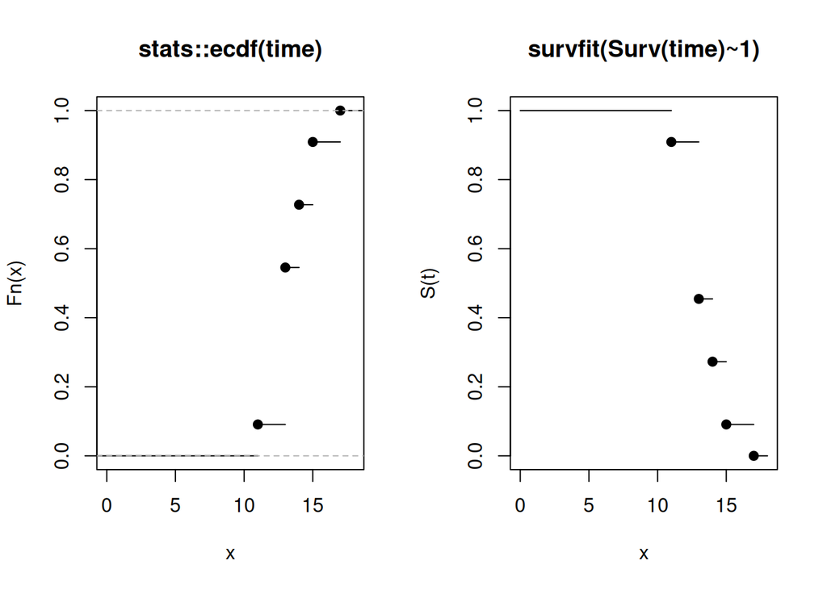

```r
library(survival)
time = c(11, 13, 13, 13, 13, 13, 14, 14, 15, 15, 17)
par(mfrow=1:2) # graphics layout with 1 row and 2 columns
## see also graphics::layout() or solutions using grid graphics
plot(stats::ecdf(time), xlim=c(0,18))
survival::survfit(survival::Surv(time)~1) |>
    with({
        plot(time, surv, type="p", pch=19, xlab="x", ylab="S(t)",
             main="survfit(Surv(time)~1)", xlim=c(0,18), ylim=0:1)
        segments(c(0,time), c(1,surv), x1=c(time,18))
    })
```

## Reminder: Estimands, estimators and estimates

- An **estimand** is what we (conceptually) want to calculate – which often relates to our research question. An example is the proportion of individuals who are alive at five years after study entry.
- An **estimator** is a calculation process (e.g. a formula or an algorithm) to calculate an estimate. An example is the Kaplan-Meier estimator for survival (that is, the formula).
- An **estimate** is the resulting calculation from applying an estimator to some data. An example would be the ``estimated'' five-year survival from a Kaplan-Meier estimator from a particular study with follow-up to a specific date.
- We often need to consider how to interpret an estimator for a given study design. (For example, an odds ratio estimate using a conditional logistic regression estimator from a nested case-control study with incidence density sampling can be interpreted as a hazard ratio – which may be the estimand of interest.)

## Reminder: survival through a partition of time

- Partition the interval $(0,t]$ is divided into $m$ time intervals with an index $j = 1,2,\ldots,m$, with times $t_j$, such that $t_0=0 < t_1 < \cdots < t_m=t$.
- Then $S(t) = \prod_{j=1}^m Pr(T>t_j|T\geq t_{j-1}) = \prod_{j=1}^m p_j$
- That is, survival across the interval is the product of the conditional survival for each of the intervals $(t_{j-1},t_j]$
- This is the basic mechanism for both the life-table estimator and the Kaplan-Meier estimator.

## Life-table estimator of the survival function (Collett 2.1.1)

- Also known as the **actuarial estimator** of the survival function
- Follow-up is divided into $m$ time intervals with an index $j = 1,2,\ldots,m$, with times $t_j$, such that $t_0=0 < t_1 < \cdots < t_m=\infty$.
- Let $d_j$ be the number of events and $c_j$ be the number of censored observations within the interval $[t_{j-1},t_j)$, with $n_j$ at risk at the start of the interval (that is, at $t_{j-1}$).
- Mid-point approximation: assume that the censoring happens half-way through the interval.
- Then we have an **adjusted number at risk** $n'_j=n_j-c_j/2$
- Then $Pr(T>t_j|T\geq t_{j-1})=1 - \displaystyle \frac{d_j}{n'_j}$
- And then the life-table estimator for survival is

$$\begin{align*}
S^*(t) &= \prod_{i: t_i<t} Pr(T>t_i|T\geq t_{i-1}) \\
&= \prod_{i: t_i<t} \left(1-\frac{d_j}{n'_i}\right)
\end{align*}$$

**Exercise: Discuss whether the actuarial estimates should be joined using linear interpolation or using a piecewise contant curve (steps). What are the advantages and disadvantages of each approach?**

## R packages: collett and biostat3

- Datasets from the Collett book are provided by the publisher as .zip file. With permission from the publisher and Professor Collett, I have put a package **collett** onto CRAN.
- Reminder: "CRAN" is the Comprehensive R Archive Network, which is the most common way to share R packages.
- It would be useful to further develop the **collett** package during the course.
  - I have provided only basic documentation for some the datasets in the package – and this could be improved.
  - We could also add further examples from the book into the package.
  - Code repo: https://github.com/mclements/collett

```r
library(collett)
## help (commented out)
## ?collett::myeloma
```

- We will also use datasets (and a few functions) from another R package that I maintain: **biostat3**

## Table 2.1

```r
library(biostat3) # lifetab2(), which adapts KM::lifetab() to use Surv()
library(collett)  # myeloma
actuarial = lifetab2(Surv(time,status)~1, data=collett::myeloma,
                     breaks=c(seq(0,60,by=12), Inf))
with(actuarial,
     data.frame(period=paste0(tstart,"-"),
                nevent,nlost,nsubs,nrisk,surv1=1-nevent/nrisk,surv))
```

```
##   period nevent nlost nsubs nrisk     surv1      surv
## 1     0-     16     4    48  46.0 0.6521739 1.0000000
## 2    12-     10     4    28  26.0 0.6153846 0.6521739
## 3    24-      1     0    14  14.0 0.9285714 0.4013378
## 4    36-      3     1    13  12.5 0.7600000 0.3726708
## 5    48-      2     2     9   8.0 0.7500000 0.2832298
## 6    60-      4     1     5   4.5 0.1111111 0.2124224
```

## Figure 2.2

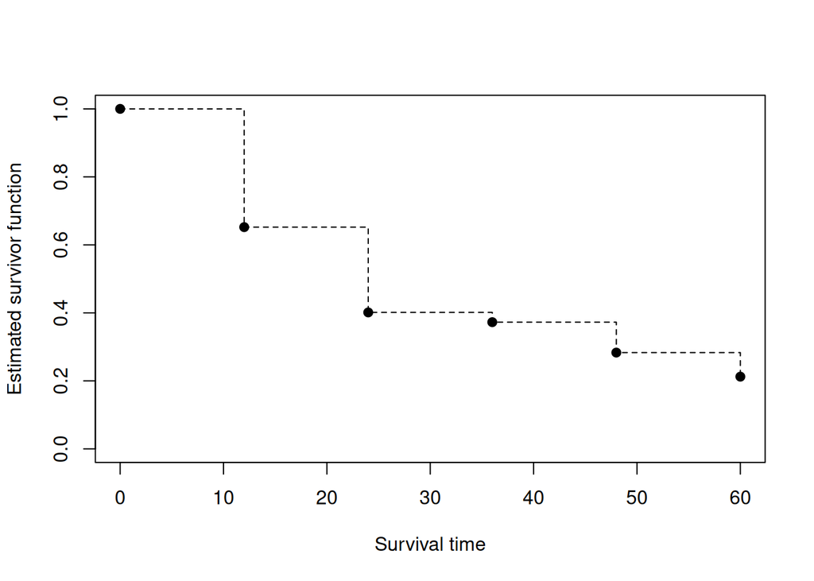

```r
plot(actuarial, type="p", pch=19,
     xlab="Survival time", ylab="Estimated survivor function",
     ylim=0:1)
lines(actuarial, type="s", lty=2)
```

## R: Semantics for pipes

```r
library(magrittr) # %>%, %T>%
## default pipes: replace first argument
log(32,2) # standard function call
```

```
## [1] 5
```

```r
32 |> log(2)  # internal pipe
```

```
## [1] 5
```

```r
32 %>% log(2)
```

```
## [1] 5
```

```r
##
rbind(1:2,3:4) # standard function call: rbind(...)
```

```
##      [,1] [,2]
## [1,]    1    2
## [2,]    3    4
```

```r
do.call(rbind, list(1:2,3:4)) # construct args from a list
```

```
##      [,1] [,2]
## [1,]    1    2
## [2,]    3    4
```

```r
do.call(what=rbind, args=list(1:2,3:4)) # with named arguments
```

```
##      [,1] [,2]
## [1,]    1    2
## [2,]    3    4
```

```r
list(1:2,3:4) |> do.call(what=rbind) # specify first => insert second
```

```
##      [,1] [,2]
## [1,]    1    2
## [2,]    3    4
```

```r
list(1:2,3:4) |> do.call(rbind, args=_) # use _ with *named* arg
```

```
##      [,1] [,2]
## [1,]    1    2
## [2,]    3    4
```

```r
list(1:2,3:4) %>% do.call(rbind, .) # . is more flexible
```

```
##      [,1] [,2]
## [1,]    1    2
## [2,]    3    4
```

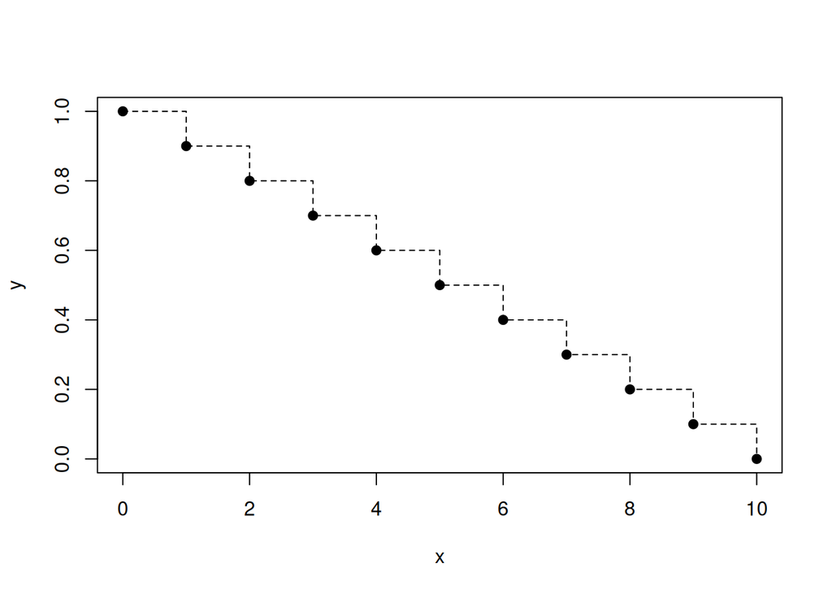

```r
##
d = data.frame(x=0:10, y=seq(1,0,len=11))
plot(d,type="s",lty=2); points(d,pch=19) # short:)
d %T>% plot(type="s",lty=2) |> points(pch=19) # elegant
```

```r
tee <- function(x, f, ...) {
    f(x, ...); invisible(x)
}
d |> tee(plot,type="s",lty=2) |> points(pch=19)
```

## Figure 2.2 with a finer time partition

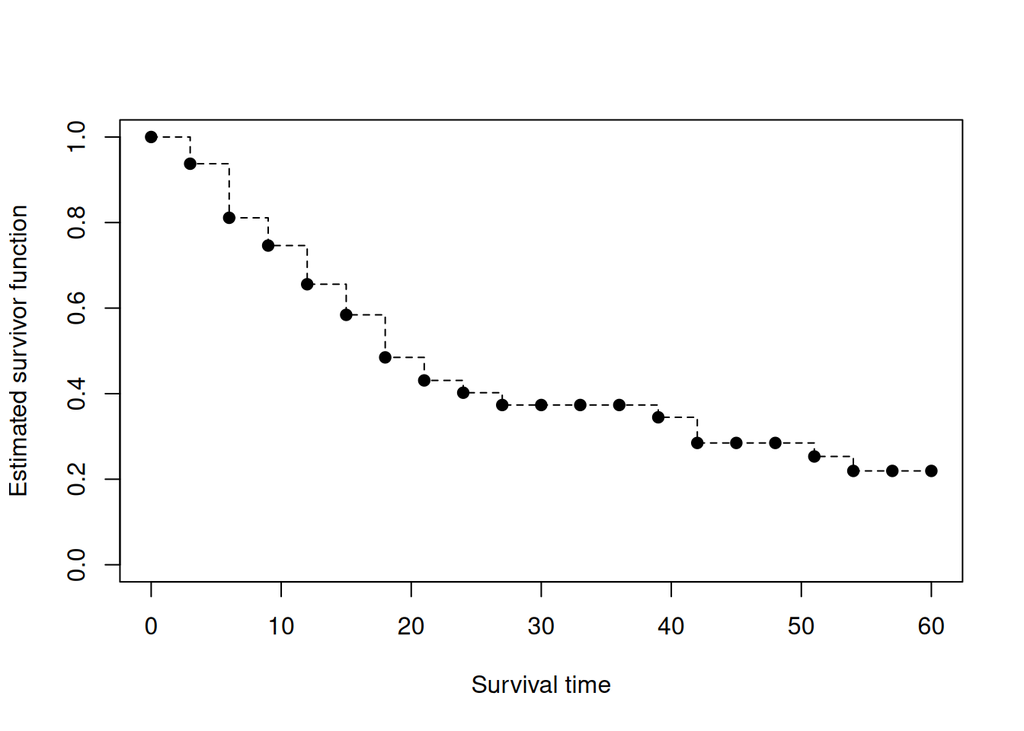

```r
library("magrittr")
lifetab2(Surv(time,status)~1, data=collett::myeloma,
         breaks=c(seq(0,60,by=3), Inf)) %T>%
    plot(type="p", pch=19,
         xlab="Survival time", ylab="Estimated survivor function",
         ylim=0:1) |>
    lines(type="s",lty=2)
```

## Kaplan-Meier estimator of the survival function (Collett 2.1.2)

- The **Kaplan-Meier estimator** is the most common approach to estimating survival from right-censored time-to-event data.
- Consider the ordered distinct event times $t_{(j)}$.
- Let $n_j$ be the number at risk immediately before $t_{(j)}$.
- Let $d_j$ at the number of events at $t_{(j)}$.
- Assume that tied censored values at event time $t_{(j)}$ happen immediately *after* the event.
- Then the Kaplan-Meier estimator is

$$\begin{align*}
\hat{S}(t) &= \prod_{i: t_{(i)}<t}
\left(1-\frac{d_i}{n_i}\right)
\end{align*}$$

## Table 2.2

```r
survfit(Surv(time,status)~1, data=IUD, conf.type="none") |>
    summary()
```

```
## Call: survfit(formula = Surv(time, status) ~ 1, data = IUD, conf.type = "none")
##
##  time n.risk n.event survival std.err
##    10     18       1    0.944  0.0540
##    19     15       1    0.881  0.0790
##    30     13       1    0.814  0.0978
##    36     12       1    0.746  0.1107
##    59      8       1    0.653  0.1303
##    75      7       1    0.559  0.1412
##    93      6       1    0.466  0.1452
##    97      5       1    0.373  0.1430
##   107      3       1    0.249  0.1392
```

## Figure 2.4: Kaplan-Meier estimates of the survival function for the IUD dataset

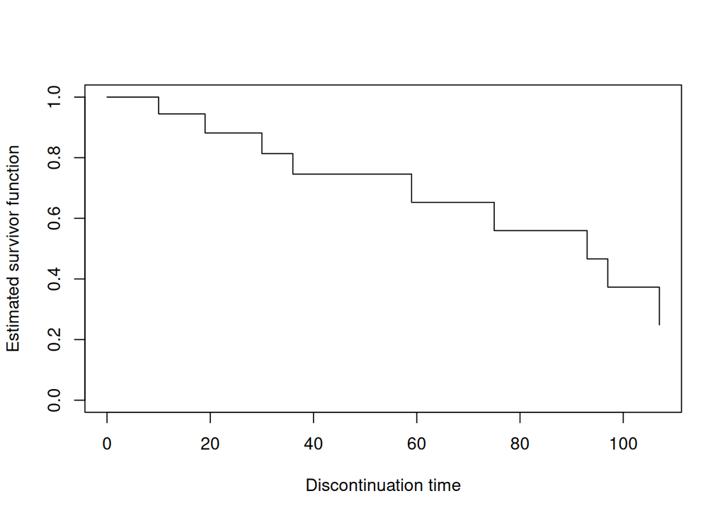

```r
survfit(Surv(time,status)~1, data=IUD) |>
    plot(xlab="Discontinuation time",
         ylab="Estimated survivor function",
         conf.int=FALSE, ylim=0:1)
```

## Nelson-Aalen estimator of the cumulative hazard function (Collett 2.1.3)

- Under similar assumptions to the Kaplan-Meier estimator, we can estimate the **cumulative hazard** to time $t$ using the **Nelson-Aalen estimator**, such that

$$\begin{align*}
\tilde{H}(t) &= \sum_{i: t_{(i)}<t} \frac{d_i}{n_i} \\
\tilde{S}(t) &= \exp\left(-\sum_{i: t_{(i)}<t}
\frac{d_i}{n_i}\right) \\
&= \prod_{i: t_{(i)}<t} \exp\left(- \frac{d_i}{n_i}\right)
\end{align*}$$

- Based on the Taylor series expansion $\exp(-x)=1-x+x^2/2-o(x^3)$. For $0 \leq x \ll 1$, we have that $\exp(-x) \geq 1-x$. This implies that $\tilde{S}(t) \geq \hat{S}(t)$.
- Collett notes that the Nelson-Aalen estimator has lower bias than the Kaplan-Meier estimator for small samples.
- Irrespectively, the Kaplan-Meier estimator is much more commonly used than the Nelson-Aalen estimator.

## Table 2.3: Nelson-Aalen estimates of the survival function for the IUD dataset

```r
survfit(Surv(time,status)~1, data=IUD, stype=2, conf.type="none") |>
    summary()
```

```
## Call: survfit(formula = Surv(time, status) ~ 1, data = IUD, stype = 2,
##     conf.type = "none")
##
##  time n.risk n.event survival std.err
##    10     18       1    0.946  0.0526
##    19     15       1    0.885  0.0768
##    30     13       1    0.819  0.0950
##    36     12       1    0.754  0.1077
##    59      8       1    0.665  0.1263
##    75      7       1    0.577  0.1370
##    93      6       1    0.488  0.1417
##    97      5       1    0.400  0.1409
##   107      3       1    0.286  0.1389
```

## Comparison of the estimators of the survival function for the myeloma dataset

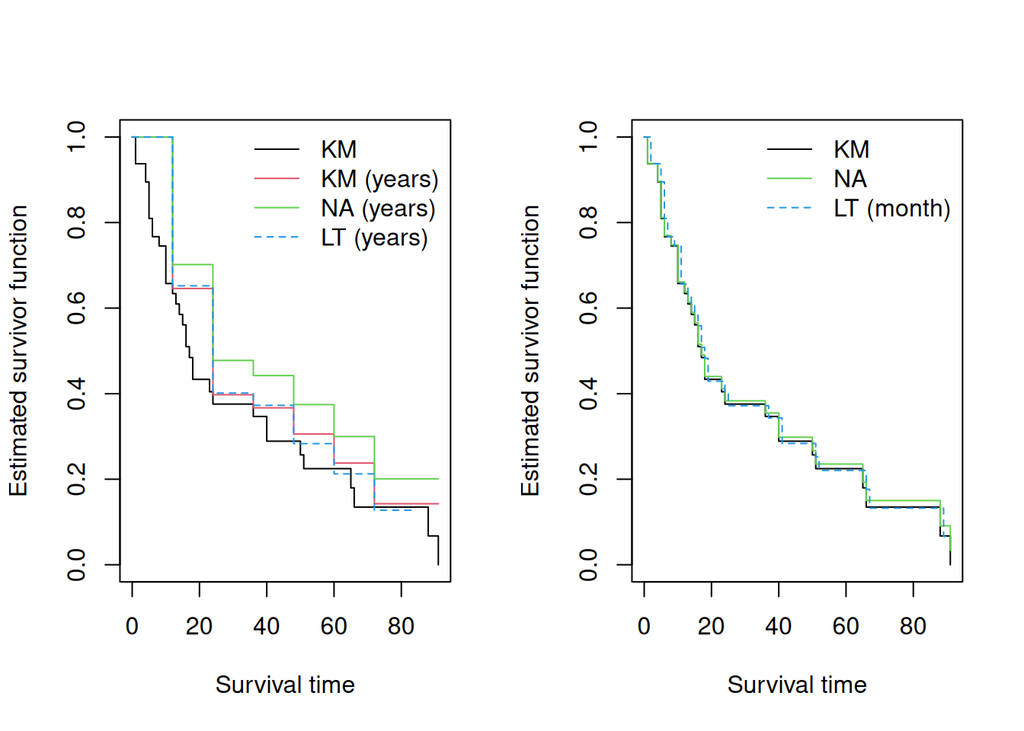

```r
par(mfrow=1:2)
survfit(Surv(time,status)~1, data=collett::myeloma) |>
    plot(xlab="Survival time", ylab="Estimated survivor function",
         conf.int=FALSE, ylim=0:1, col=1)
survfit(Surv(time,status)~1, data=transform(collett::myeloma,time=12*ceiling(time/12))) |>
    lines(conf.int=FALSE, col=2)
survfit(Surv(time,status)~1, stype=2,
        data=transform(collett::myeloma,time=12*ceiling(time/12))) |>
    lines(conf.int=FALSE, col=3)
lifetab2(Surv(time,status)~1, data=collett::myeloma,
         breaks=c(seq(0,90,by=12), Inf)) |>
    lines(type="s", lty=2, col=4)
legend("topright", legend=c("KM","KM (years)","NA (years)","LT (years)"),
       lty=c(1,1,1,2), col=1:4, bty="n")
##
survfit(Surv(time,status)~1, data=collett::myeloma) |>
    plot(xlab="Survival time", ylab="Estimated survivor function",
         conf.int=FALSE, ylim=0:1, col=1)
survfit(Surv(time,status)~1, stype=2, ctype=2, data=collett::myeloma) |>
    lines(conf.int=FALSE, col=3)
lifetab2(Surv(time,status)~1, data=collett::myeloma,
         breaks=c(seq(0,90,by=1), Inf)) |>
    lines(type="s", col=4, lty=2)
legend("topright", legend=c("KM","NA","LT (month)"),
       lty=c(1,1,2), col=c(1,3:4), bty="n")
```

## Reminder: delta method

- The **delta method** is one of the more useful tools in statistics. For a random variable $\boldsymbol{X}$ and $g : \mathbb{R}^n \rightarrow \mathbb{R}$, then by convention the gradient $g'(\boldsymbol{X})$ is a column vector of length $n$ and the variance of $g(\boldsymbol{X})$ can be approximated by

$$\begin{align*}
\text{var}(g(\boldsymbol{X}))^T &\approx g'(\boldsymbol{X})^T
\text{var}(\boldsymbol{X}) g'(\boldsymbol{X})
\end{align*}$$

- For $\boldsymbol{g} : \mathbb{R}^n \rightarrow \mathbb{R}^m$, then by convention the Jacobian $\nabla \boldsymbol{g}(\boldsymbol{X})$ is a matrix with $m$ rows and $n$ columns and the variance of $\boldsymbol{g}(\boldsymbol{X})$ can be approximated by

$$\begin{align*}
\text{var}(\boldsymbol{g}(\boldsymbol{X})) &\approx
\nabla\boldsymbol{g}(\boldsymbol{X}) \text{var}(\boldsymbol{X})
\nabla\boldsymbol{g}(\boldsymbol{X})^T
\end{align*}$$

- For a vector $\boldsymbol{g}$, we will obtain a variance-covariance matrix, that includes the variances on the diagonal and covariance terms on the off-diagonal.
  - If the vector transformation is long, then the variance-covariance matrix can be very large and we can use a short-cut to get at the variances on the diagonal:

$$\begin{align*}
\text{diag}(\text{var}(\boldsymbol{g}(\boldsymbol{X}))) &\approx
\left(\left(\nabla\boldsymbol{g}(\boldsymbol{X})
\text{var}(\boldsymbol{X})\right) \circ
\nabla\boldsymbol{g}(\boldsymbol{X})\right) \boldsymbol{1}
\end{align*}$$

where $\boldsymbol{M}_1 \circ \boldsymbol{M}_2$ represents the Hadamard (element-wise) product of matrices $\boldsymbol{M}_1$ and $\boldsymbol{M}_2$.

- For an example using a univariate random variable and univariate transformation: for $g(X)=\log(X)$, then $\text{var}(\log(X))\approx \text{var}(X)(g'(X))^2=\text{var}(X)/X^2$.
- The Jacobians/gradients can be calculated analytically or using finite differences.

## Variance for Kaplan-Meier estimator

For the Kaplan-Meier estimator $\hat{S}(t)$,

$$\begin{align*}
\hat{S}(t) &= \prod_{j: t_{(j)}<t} \frac{n_j-d_j}{n_j} \\
\implies \log(\hat{S}(t)) &= \sum_{j: t_{(j)}<t}
\log\left(\frac{n_j-d_j}{n_j}\right) \\
\implies \text{var}(\log(\hat{S}(t))) &= \sum_{j: t_{(j)}<t}
\text{var}\left(\log\left(\frac{n_j-d_j}{n_j}\right))\right) \\
&\approx \sum_{j: t_{(j)}<t}
\text{var}\left(\frac{n_j-d_j}{n_j}\right) /
\left(\frac{n_j-d_j}{n_j}\right)^2 \\
&= \sum_{j: t_{(j)}<t} \frac{d_j(n_j-d_j)}{n_j^3} /
\left(\frac{n_j-d_j}{n_j}\right)^2 \\
&= \sum_{j: t_{(j)}<t} \frac{d_j}{n_j(n_j-d_j)} \\
\end{align*}$$

## Variance for Kaplan-Meier estimator

- Note that $\text{var}(\log(\hat{S}(t)))=\text{var}(\hat{H}(t))$, which is the variance of the cumulative hazard.
- Again using the delta method, we have that

$$\begin{align*}
\text{var}(\log(\hat{S}(t))) &\approx
\text{var}(\hat{S}(t))/(\hat{S}(t))^2 \\
\implies \text{var}(\hat{S}(t)) &\approx (\hat{S}(t))^2
\text{var}(\log(\hat{S}(t))) \\
&\approx (\hat{S}(t))^2 \sum_{j: t_{(j)}<t}
\frac{d_j}{n_j(n_j-d_j)}
\end{align*}$$

- This result is known as **Greenwood's formula**

## Variances for the other estimators

$$\begin{align*}
\text{var}(\log(S^*(t))) &\approx (S^*(t))^2 \sum_{j}
\frac{d_j}{n_j'(n_j'-d_j)} \\
\text{var}(\log(\tilde{S}(t))) &\approx (\tilde{S}(t))^2 \sum_{j:
t_{(j)}<t} \frac{d_j}{n_j^2}
\end{align*}$$

## Confidence intervals

- For calculating confidence intervals, we would prefer a transformation of survival that is symmetric and ensures values that are between zero and 1.
- A common transformation is $\log(-\log(S))$. We already have an estimate of $\text{var}(\log(\hat{S}))$, so again using our result for $\text{var}(\log(X))$, we have that

$$\begin{align*}
\text{var}(\log(-\log(\hat{S}(t)))) &\approx
\text{var}(\log(\hat{S}(t))) / (\log(\hat{S}(t)))^2 \\
&= \frac{1}{(\log(\hat{S}(t)))^2} \sum_{j: t_{(j)}<t}
\frac{d_j}{n_j(n_j-d_j)}
\end{align*}$$

## Confidence intervals

- We can then use Wald-type confidence intervals on the transformed scale:

$$\begin{align*}
\log(-\log(\hat{S}(t))) \pm z_{1-\alpha/2}
\sqrt{\text{var}(\log(-\log(\hat{S}(t))))}
\end{align*}$$

where $z$ is a normal quantile for (e.g. $\alpha=0.05$).

- We can then back-transform to the survival scale

$$\begin{align*}
\hat{S}(t)^{\exp\left(\pm z_{1-\alpha/2}
\sqrt{\text{var}(\log(-\log(\hat{S}(t))))}\right)}
\end{align*}$$

## Using the Maxima computer algebra software:

```
delta_method(g,X,varX) := diff(g,X) * varX * diff(g,X)$
tex(delta_method(log(-log(S)), S, varS));
tex(delta_method(log(-logS), logS, varlogS));
```

$${{{\it varS}}\over{S^2\,\left(\log
S\right)^2}}$$
$${{{\it
varlogS}}\over{{\it logS}^2}}$$

## Confidence intervals based on conf.type="plain"

```r
survfit(Surv(time,status)~1, data=IUD, conf.type="plain") |> summary()
```

```
## Call: survfit(formula = Surv(time, status) ~ 1, data = IUD, conf.type = "plain")
##
##  time n.risk n.event survival std.err lower 95% CI upper 95% CI
##    10     18       1    0.944  0.0540       0.8386        1.000
##    19     15       1    0.881  0.0790       0.7267        1.000
##    30     13       1    0.814  0.0978       0.6220        1.000
##    36     12       1    0.746  0.1107       0.5290        0.963
##    59      8       1    0.653  0.1303       0.3972        0.908
##    75      7       1    0.559  0.1412       0.2827        0.836
##    93      6       1    0.466  0.1452       0.1816        0.751
##    97      5       1    0.373  0.1430       0.0927        0.653
##   107      3       1    0.249  0.1392       0.0000        0.522
```

## Confidence intervals based on conf.type="log-log"

```r
survfit(Surv(time,status)~1, data=IUD, conf.type="log-log") |> summary()
```

```
## Call: survfit(formula = Surv(time, status) ~ 1, data = IUD, conf.type = "log-log")
##
##  time n.risk n.event survival std.err lower 95% CI upper 95% CI
##    10     18       1    0.944  0.0540       0.6664        0.992
##    19     15       1    0.881  0.0790       0.6019        0.969
##    30     13       1    0.814  0.0978       0.5241        0.936
##    36     12       1    0.746  0.1107       0.4536        0.897
##    59      8       1    0.653  0.1303       0.3438        0.843
##    75      7       1    0.559  0.1412       0.2564        0.780
##    93      6       1    0.466  0.1452       0.1830        0.710
##    97      5       1    0.373  0.1430       0.1209        0.631
##   107      3       1    0.249  0.1392       0.0468        0.531
```

## Confidence intervals based on `conf.type`"log-log"=

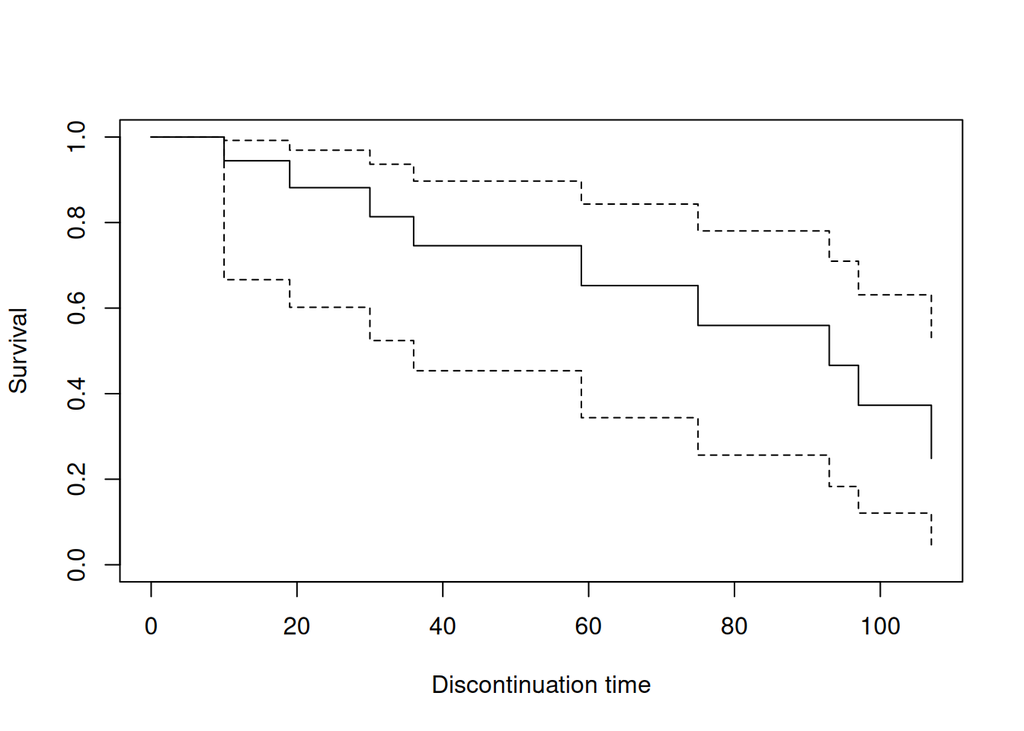

```r
survfit(Surv(time,status)~1, data=IUD, conf.type="log-log") |>
    plot(xlab="Discontinuation time", ylab="Survival")
```

## Extension: survival estimation including left-truncation and right censoring

- This is a straightforward extension, as we simply change the risk set and the **number at risk $n<sub>i</sub>$**.
- However, the interpretation of "survival" then becomes more complex, as the estimator assumes that those at risk at a particular time would be representative for a cohort that is followed from time $0$.
- Moreover, if there are none at risk at an earlier time, then there is **no risk** of an event – which is a form of **immortal time bias**.
- Finally, if there are very few at risk, then the estimator will be imprecise, which will affect how to interpret the findings.
- We will return to these issues when we review the article by Lei et al (2020).

## Rate calculations: actuarial approach (Collett 2.3.1)

- For the actuarial approach, let $\tau_j$ be the width of the $j\text{-th}$ time interval. Assuming a that the deaths on average happen half-way through the interval, then the person-time at risk is approximately $(n_j'-d_j/2)\tau_j$ and the hazard estimator is

$$\begin{align*}
h^*(t) &= \frac{d_j}{(n_j'-d_j/2)\tau_j}
\end{align*}$$

- Assuming a **multinomial distribution**, Collett provides an estimate of the variance [@gehan1969estimating]:

$$\begin{align*}
\text{var}(h^*(t)) &= h^*(t)^2(1-(h^*(t)\tau_j)^2)/d_j
\end{align*}$$

## Rate calculations assuming person-time and Poisson counts

- A more precise approach for interval $j$ is to report the overlaps of individual follow-up with the interval splits to calculate **person-time** $\text{PT}_j$. This neatly avoids the mid-point approximations for the censored events and the deaths. We would then have

$$\begin{align*}
h^*(t) &= \frac{d_j}{\text{PT}_j}
\end{align*}$$

- Assuming that the counts $d_j$ are **Poisson distributed**, then $E(d_j)=\text{var}(d_j)=d_j$ and $\text{var}(\log(d_j))=1/d_j$

$$\begin{align*}
\text{var}(h^*(t)) &= \text{var}(d_j)/\text{PT}_j^2 =
d_j^2\text{var}(\log(d_j)/\text{PT}_j^2 \\
&= d_j^2/d_j/\text{PT}_j^2 = h^*(t)^2/d_j
\end{align*}$$

## Smoothing the Nelson-Aalen estimator (Collett 2.3.2; Aalen et al 2008, section 3.1.4)

- The **hazard** can be estimated by smoothing the steps in the Nelson-Aalen estimator.
- For distinct event times $t_{(j)}$, with number of events $d_j$ and number at risk $n_j$, the smoothed hazard can be estimated by

$$\begin{align*}
h^\dagger(t) &= \frac{1}{b}\sum_j
K\left(\frac{t-t_{(j)}}{b}\right) \frac{d_j}{n_j} \\
&= \frac{1}{b}\sum_j K\left(\frac{t-t_{(j)}}{b}\right)
\Delta\hat{H}(t_{(j)})
\end{align*}$$

where $b$ is a **bandwidth** and the **kernel function** $K(x)$ is a bounded function that vanishes outside of $[-1,1]$ and has integral 1.

- Example kernels include:
  - **Epanechnikov** kernel $K(x) = \frac{3}{4} (1-x^2)$, which is shown in Collett (2023)
  - **biweight** kernel $K(x)=\frac{15}{16} (1-x^2)^2$
- Importantly, the bandwidth $b$ needs to be selected.
- Since the increments in the Nelson-Aalen estimator are independent, an estimate of the variance can be calculated by:

$$\begin{align*}
\text{var}\left(h^\dagger(t)\right)
&= \frac{1}{b^2}\sum_j K\left(\frac{t-t_{(j)}}{b}\right)^2
\Delta\hat{\sigma}^2(t_{(j)}) \\
&= \frac{1}{b^2}\sum_j K\left(\frac{t-t_{(j)}}{b}\right)^2
\text{var}(\frac{d_j}{n_j}) \\
&= \frac{1}{b^2}\sum_j K\left(\frac{t-t_{(j)}}{b}\right)^2
\frac{d_j}{n_j^2}
\end{align*}$$

## Exercise: exponential distribution

- An **exponential distribution** has a **constant hazard** $h$.
- What are the following quantities?
  - Cumulative distribution function
  - Survival function
  - Probability density function
  - Cumulative hazard
  - Quantile function $t(p)$, which is the time when a proportion $p$ of individuals have experienced the event:

$$\begin{align*}
t(p) &= \underset{t_i}{\text{min}}\{\hat{F}(t_i) \geq p\} \\
&= \underset{t_i}{\text{min}}\{\hat{S}(t_i) < 1-p\}
\end{align*}$$

- Assuming independence between individuals, for **person-time** PT, what is the expected number of events? What distribution is expected for the number of events?

## Reminder: Kernel density estimation

- Kernel density estimation is a closely related form where we seeking to estimate the probability density function $f^\dagger(t)$ given a sample $t_j$.

$$\begin{align*}
f^\dagger(t) &= \frac{1}{b}\sum_j K\left(\frac{t-t_j}{b}\right)
\frac{1}{n} \\
\end{align*}$$

- We see that we have replaced the weights $d_j/n_j$ with $1/n$.
- Automatic bandwidth estimation is difficult under general conditions.
- One issue to be aware of is that a boundary in the data can bias the estimated density. There are standard methods to reduce that bias.
- Hazard estimation is essentially a weighted form of kernel density estimation.
- There are many methods and implementations for kernel density estimation.
  - **stats::density()** is available from base R
  - **KernSmooth::bkde()** is a standard implementation

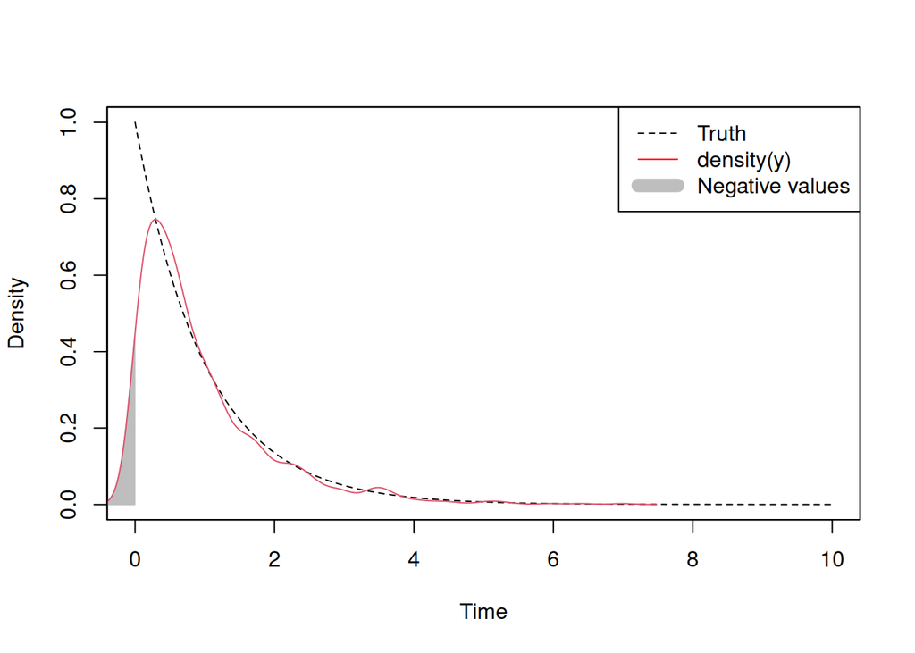

```r
set.seed(12345)
y = rexp(1e3) # exponential: constant hazard
den1 = density(y)
with(list(x=seq(0,10,length=401L)),
     plot(x, dexp(x), lty=2, type="l",
          xlab="Time", ylab="Density", main=""))
with(den1, {
    index = (x<0)
    x = x[index]
    polygon(c(x,rev(x)), c(y[index], x*0), col="grey", border="grey")
    })
lines(den1, col=2)
legend("topright", legend=c("Truth","density(y)","Negative values"), lty=c(2,1,1), col=c("black","red","grey"), lwd=c(1,1,10))
box()
```

```r
library(evmix)
```

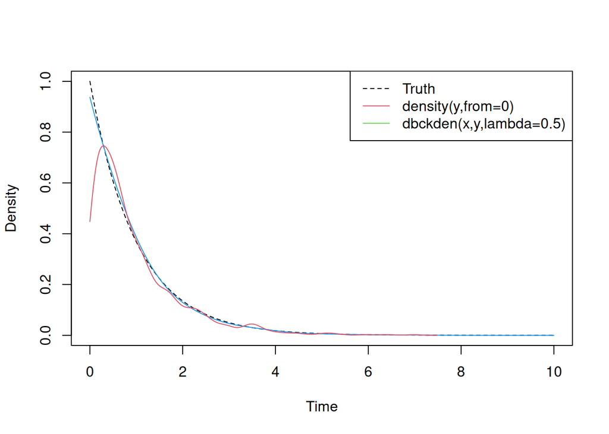

```r
set.seed(12345)
y = rexp(1e3) # exponential: constant hazard
with(list(x=seq(0,10,length=401L)), {
    plot(x, dexp(x), lty=2, type="l",
         xlab="Time", ylab="Density", main="")
    lines(x,dbckden(x,y,lambda=0.5),col=4)
})
lines(density(y,from=0),col=2)
legend("topright", legend=c("Truth","density(y,from=0)","dbckden(x,y,lambda=0.5)"),
       lty=c(2,1,1), col=c(1,2,3))
```

## Hazard estimation: standard implementations

- There is an old R package **muhaz** for hazard estimation of right-censored data. It is not currently available on **webR**. A wrapper for this is available from the **biostat3** package.
- The **bshazard** package allows for left truncation, right censoring, and confidence interval estimation [@rebora2014bshazard].

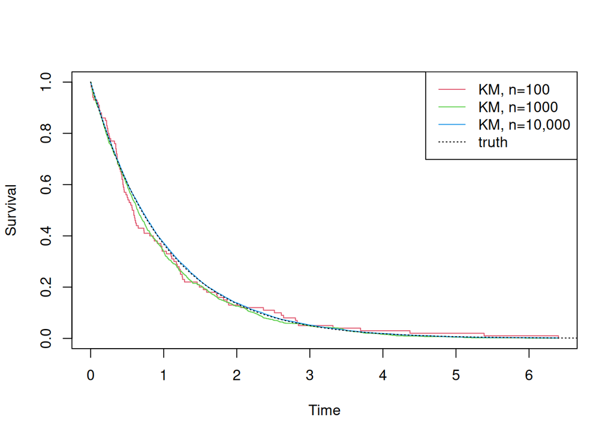

```r
library(survival) # survfit()
par(mfrow=c(1,1))
set.seed(12345)
data.frame(y=rexp(1e2)) |> # exponential: constant hazard
    with(plot(survfit(Surv(y)~1),col=2,conf.int=FALSE,
              xlab="Time", ylab="Survival"))
data.frame(y=rexp(1e3)) |>
    with(lines(survfit(Surv(y)~1),col=3,conf.int=FALSE))
data.frame(y=rexp(1e4)) |>
    with(lines(survfit(Surv(y)~1),col=4,conf.int=FALSE))
with(list(x=seq(0,10,length=401L)), lines(x,exp(-x),lty=3))
legend("topright",legend=c("KM, n=100","KM, n=1000","KM, n=10,000","truth"),
       col=c(2,3,4,1),lty=c(1,1,1,3))
```

```r
library(biostat3) # muhaz2()
library(bshazard) # bshazard()
```

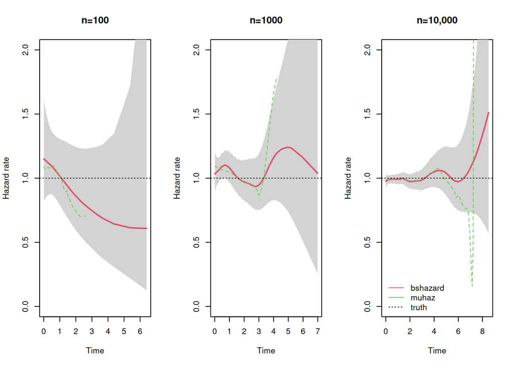

```r
par(mfrow=c(1,3))
set.seed(12345)
d = data.frame(y=rexp(1e2),e=TRUE) # exponential: constant hazard
plot(bshazard(Surv(y)~1,data=d,verbose=FALSE),col=2,ylim=c(0,2),
     main="n=100")
lines(muhaz2(Surv(y,e)~1, data=d), lty=2, col=3) # no confidence intervals
abline(h=1,lty=3)
##
d = data.frame(y=rexp(1e3),e=TRUE)
plot(bshazard(Surv(y)~1,data=d,verbose=FALSE),col=2,ylim=c(0,2),
     main="n=1000")
lines(muhaz2(Surv(y,e)~1, data=d), lty=2, col=3) # no confidence intervals
abline(h=1,lty=3)
##
d = data.frame(y=rexp(1e4),e=TRUE)
plot(bshazard(Surv(y)~1,data=d,verbose=FALSE),col=2,ylim=c(0,2),
     main="n=10,000")
lines(muhaz2(Surv(y,e)~1, data=d), lty=2, col=3) # no confidence intervals
abline(h=1,lty=3)
legend("bottomleft", legend=c("bshazard","muhaz","truth"), col=c(2,3,1),
       lty=c(1,1,3), bty="n")
```

## Quantiles for survival

- Collett shows that

$$\begin{align*}
\text{var}(t(p)) &= \text{var}(\hat{S}(t(p)))/\hat{f}(t(p))^2
\end{align*}$$

- For details, including how to calculate $\hat{f}(t(p))$ and the variance of the quantile see Collett, sections 2.4-2.5.
- TODO: decide whether to (a) make this an exercise, (b) remove this material or (c) add this material.

## Exercise: when to look and when to test?

- Consider that you are the biostatistician on an observational study for breast cancer patients (see the documentation for `collett::bcancer`).
- One of the investigators suggests that you assess whether staining with *Helix pomatia* agglutinin is associated with improved survival.
- What should you do **first**?
  1. Plot the survival curves for each group?
  2. Plot the hazard curves for each group?
  3. Formally test for a difference between the groups? (Let's assume that we initially do *not* want to estimate a hazard ratio.)
  4. Do something else? (If so: what?)

## Comparison of two groups of survival data (Collett 2.6)

- Is there evidence that the curves are different?

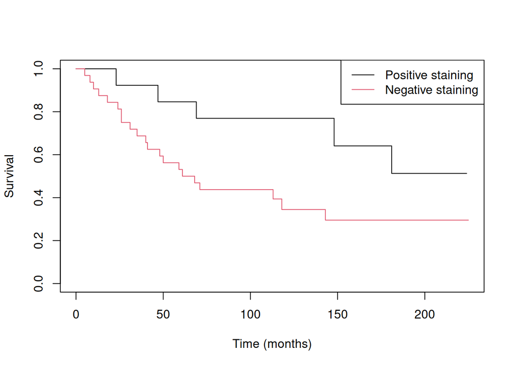

```r
survfit(Surv(time,status)~stain, data=bcancer) |>
    plot(xlab="Time (months)", ylab="Survival", col=1:2)
legend("topright",
       legend=c("Positive staining","Negative staining"),
       col=1:2, lty=1)
```

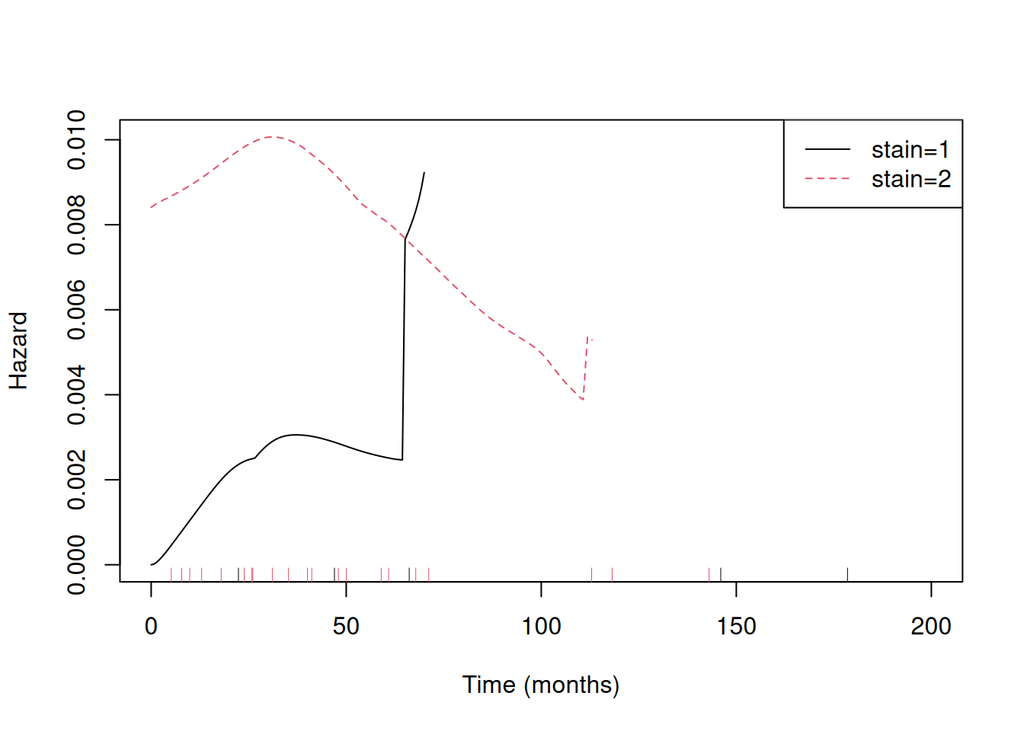

```r
set.seed(54321)
muhaz2(Surv(time,status)~stain, data=bcancer) |>
    plot(xlab="Time (months)", ylab="Hazard", col=1:2, xlim=c(0,200))
with(subset(bcancer, status==1 & stain==1),
     rug(jitter(time)))
with(subset(bcancer, status==1 & stain==2),
     rug(jitter(time),col=2))
```

## Log-rank test (Collett 2.6.2)

- Consider that we have two groups: group I and group II
- Let the distinct times for the events be $t_{(1)} < t_{(2)} < \cdots < t_{(r)}$ for $r$ distinct times across the two groups.
- Extending our previous notation:
  - Let $d_{ij}$ be the number of events in group $i$ at time $t_{(j)}$.
  - Let $n_{ij}$ be the number of at risk in group $i$ just before time $t_{(j)}$.
  - We have $d_j=\sum_i d_{ij}$ and $n_j=\sum_i n_{ij}$.
- Our **null hypothesis** is that there is **no difference between the two groups**.
- For each time $t_{(j)}$, we have the following table:

| Group | Number of deaths | Number surviving | Number at risk |
| --- | --- | --- | --- |
|  | at $t_{(j)}$ | beyond $t_{(j)}$ | just before $t_{(j)}$ |
| I | $d_{1j}$ | $n_{1j}-d_{1j}$ | $n_{1j}$ |
| II | $d_{2j}$ | $n_{2j}-d_{2j}$ | $n_{2j}$ |
| Total | $d_j$ | $n_j-d_j$ | $n_j$ |

- Assume that the column totals (the last row) and the row totals (the last column) are **fixed**.
- Under the null hypothesis, the $d_{ij}$ have a **hypergeometric distribution**.
- Consequently, the probability that the first cell will be $d_{1j}$ will be $\binom{d_j}{d_{1j}}\binom{n_j-d_j}{n_{1j}-d_{1j}}/\binom{n_j}{n_{1j}}$.
- Moreover, the expected value of $d_{1j}$ under the null hypothesis will be $e_{1j}=n_{1j} d_j/n_j$.
- To combine the observed and expected values across the distinct event times, one approach is to simply sum:

$$\begin{align*}
U_L &= \sum_{j=1}^r (d_{1j}-e_{1j})
\end{align*}$$

- Under the null hypothesis, $E(d_{1j})=e_{1j}$ and $E(U_L)=0$. Further, as the event times are independent of each other (to be shown:), then

$$\begin{align*}
V_L = \text{var}(U_L) &= \sum_{j=1}^r \text{var}(d_{1j}-e_{1j}) =
\sum_{j=1}^r \frac{n_{1j}n_{2j}d_{j}(n_{j}-d_{j})}{n_{j}^2(n_{j}-1)}
\end{align*}$$

- Under the null hypothesis, we then have that

$$\begin{align*}
\frac{U_L^2}{V_L} &\sim \chi_1^2
\end{align*}$$

that is, the ratio has a chi-squared distribution with one degree of freedom.

## Example of the log-rank test

```r
d = with(bcancer,
     sort(unique(time[status==1])) |>
     sapply(function(t)
         c(d1j = sum(status==1 & stain==1 & time==t),
           n1j = sum(stain==1 & time>=t),
           n2j = sum(stain==2 & time>=t),
           dj = sum(status==1 & time==t),
           nj = sum(time>=t)))) |>
    t() |>
    as.data.frame() |>
    transform(e1j = n1j*dj/nj,
              v1j = n1j*n2j*dj*(nj-dj)/nj^2/(nj-1))
with(d,  {
    U = sum(d1j-e1j)
    V = sum(v1j)
    W = U^2/V
    pval = pchisq(W,1,lower.tail=FALSE)
    data.frame(UL=U,VL=V,WL=W,pval)
})
```

```
##          UL    VL       WL       pval
## 1 -4.565128 5.929 3.514993 0.06081591
```

```r
survdiff(Surv(time,status)~stain, data=bcancer)
```

```
## Call:
## survdiff(formula = Surv(time, status) ~ stain, data = bcancer)
##
##          N Observed Expected (O-E)^2/E (O-E)^2/V
## stain=1 13        5     9.57      2.18      3.51
## stain=2 32       21    16.43      1.27      3.51
##
##  Chisq= 3.5  on 1 degrees of freedom, p= 0.06
```

## Wilcoxon test

- Log-rank test gives similar weights to each event.
- Wilcoxon test weights by the number at risk:
  - $U_W = \sum_{j=1}^r n_j(d_{1j}-e_{1j})$

```r
with(d, {
    U = sum(nj*(d1j-e1j)) # CHANGE
    V = sum(v1j*nj^2) # CHANGE
    W = U^2/V
    pval = pchisq(W,1,lower.tail=FALSE)
    data.frame(UW=U,VW=V,WW=W,pval)
})
```

```
##     UW       VW       WW       pval
## 1 -159 6048.135 4.179966 0.04090452
```

## Peto-Peto test

- Wilcoxon test has been shown to be sensitive to different censoring patterns between groups.
- Peto-Peto test weights by the Kaplan-Meier estimates of survival at each time (combining the strata):
  - $U_P = \sum_{j=1}^r \hat{S}(t_{(j)}-)(d_{1j}-e_{1j})$
  - Note that we used survival at $t_{(j)}-$.

```r
surv1 = survfit(Surv(time,status)~1,data=bcancer) |> summary() |>
    with(c(1,head(surv,-1)))
with(d, {
    U = sum(surv1*(d1j-e1j)) # CHANGE
    V = sum(surv1^2*v1j) # CHANGE
    W = U^2/V
    pval = pchisq(W,1,lower.tail=FALSE)
    data.frame(UP=U,VP=V,WP=W,pval)
})
```

```
##          UP       VP       WP      pval
## 1 -3.603155 3.155244 4.114651 0.0425133
```

```r
survdiff(Surv(time,status)~stain, data=bcancer, rho=1)
```

```
## Call:
## survdiff(formula = Surv(time, status) ~ stain, data = bcancer,
##     rho = 1)
##
##          N Observed Expected (O-E)^2/E (O-E)^2/V
## stain=1 13      3.0      6.6      1.97      4.11
## stain=2 32     15.7     12.1      1.08      4.11
##
##  Chisq= 4.1  on 1 degrees of freedom, p= 0.04
```

## Comparison of the log-rank, Wilcoxon and Peto-Peto tests (Collett 2.6.5)

- If **proportional hazards**, then prefer the log-rank test
- For other patterns, the Peto-Peto test is preferred (for details, see Collett)

## Comparison of three or more groups of survival data (Collett 2.7)

- Collett provides details on a multivariate generalisation of the two-group tests.
- The test statistics have chi-squared distributions with $g-1$ degrees of freedom, where $g$ is the number of groups.
- For details, see Collett.

## Stratified tests (Collett 2.8)

- It is common to have key covariates that associated with both survival and the exposure of interest (e.g. age is often associated with both).
- As a straightforward generalisation of these tests, we can calculate **stratified tests**. Let the strata be indexed by $k$ with $s$ strata. Let the statistic for stratum $k$ be $U_k$ and let its variance be $V_k$. Then a stratified test would be

$$\begin{align*}
W_S &= \frac{\left(\sum_{k=1}^s U_k\right)^2}{\sum_{k=1}^s V_k}
\end{align*}$$

```r
survdiff(Surv(time,status)~treatment+strata(age), data=collett::melanoma)
```

```
## Call:
## survdiff(formula = Surv(time, status) ~ treatment + strata(age),
##     data = collett::melanoma)
##
##              N Observed Expected (O-E)^2/E (O-E)^2/V
## treatment=1 11        5     3.76     0.407     0.688
## treatment=2 19        5     6.24     0.245     0.688
##
##  Chisq= 0.7  on 1 degrees of freedom, p= 0.4
```

- As a practitioner, I have never used this stratified test – primarily because I generally prefer to model effect sizes rather than perform tests. That said, I believe that the stratified tests deserve more attention.

**Exercise: show an R implementation of a stratified log-rank test and compare your calculations with the results in Collett exercise 2.15 in section 2.8.**

## Brief review of R data types

| Type | Name | Values | Comment |
| --- | --- | --- | --- |
| `num` | numeric | 1.0, -2.0e-5 | Double precision. Assumes 1 is numeric |
| `int` | integer | 1L, 2L |  |
| `char` | character | "A", "1234" |  |
| `Factor` | factor | "A", "B" | Categories with ordered levels |
| `Date` | Date | as.Date("1969-08-01") | Difference of dates is a `difftime` – convert using `as.numeric`. |

## Colon carcinoma 1985–94

- Codes for vital status with corresponding frequency counts 1985–94

| Code and description | Male | Female |
| --- | --- | --- |
| 0 Alive | 1476 | 2081 |
| 1 Dead: due to colon carcinoma | 1806 | 2618 |
| 2 Dead: other cause of death | 519 | 586 |
| 4 Lost to follow-up | 1 | 0 |
| Total | 3802 | 5285 |

- Note that the sample data sets also include patients diagnosed

1975–1984.

## Skin melanoma 1985–94

- Codes for vital status with corresponding frequency counts 1985–94

| Code and description | Male | Female |
| --- | --- | --- |
| 0 Alive | 1554 | 1786 |
| 1 Dead: melanoma was the cause | 543 | 376 |
| 2 Dead: other cause of death | 238 | 247 |
| 4 Lost to follow-up | 0 | 0 |
| Total | 2335 | 2409 |

- Note that the sample data sets also include patients diagnosed

1975–1984.

## What has been left on the table?

- For this material, we have been informal in our approach.
- We have not shown formal assumptions (e.g. boundedness and other regularity conditions).
- We have not shown that the event statistics at different times are independent.
- We have not used Stieltjes integrals to allow for cumulative distribution functions that include both steps and continuous increases.
- Note: we will return to (most of) these considerations in later teaching occasions.

## Exercises

- See exercises Q1–4.
- Instructions for each are included in those questions.
- We will assign each group some of the questions to give a walk-through for your answers.

## Quiz

1. Define the hazard function in terms of probabilities for random variable $T$ for (a) discrete time and (b) continuous time.
2. For continuous time: what is the formula for survival $S(t)$ to time $t$ given the hazard $h(t)$?
3. Express the log-likelihood for the left truncated and potentially right censored data tuple $(\delta_i,t_{0i},t_{1i})$ for event indicator $\delta_i$, entry time $t_{t0i}$ and exit time $t_{1i}$ – in terms of the hazard and the cumulative hazard.
4. What are **three** differences between the actuarial and Kaplan-Meier estimators of survival?

## Quiz: answers

1. In discrete time:

$$\begin{align*}
h(t) = P(T=t|T \geq t) = \frac{P(T=t)}{P(T\geq t)}
\end{align*}$$

In continuous time:

$$\begin{align*}
h(t) & = \lim_{\delta \rightarrow 0} \frac{P(T \in [t,t+\delta) |
T \geq t)}{\delta} = \lim_{\delta \rightarrow 0} \frac{P(T \in
[t,t+\delta))}{\delta P(T\geq t)}
\end{align*}$$

1. Survival:

$$\begin{align*}
S(t) = \exp\left(-\int_0^t h(u) du\right)
\end{align*}$$

1. Log-likelihood:

$$\begin{align*}
l = \delta_i \log(h(t_{1i})) - H(t_{1i}) + H(t_{0i})
\end{align*}$$

1. The actuarial estimator has:
   - Pre-specified time intervals, whereas the Kaplan-Meier (KM) estimator uses the distinct event times
   - The actuarial estimator adjusts the number at risk by subtracting half of the number of censored (mid-point approximation), whereas KM assumes that everyone is at risk
   - The KM estimator assumes that censored times that tie with an event happen immediately after the event, whereas the actuarial estimator considers censored values across the interval. Arguably this is re-expressing the second point:|.